# Final Project

## Introduction of the Data Set and Modeling Problem

### The Data Set

The given data set contains payment information of 30,000 credit card holders obtained from a bank in Taiwan. Each data sample is described by 23 feature attributes. The target feature (Attribute Y) to be predicted is a binary variable, 0 (= not default) or 1 (= default).

| Attribute | Column | Column Name | Description |
| --- | --- | --- | --- |
| X1 | 2 | LIMIT_BAL | Amount of given credit in NT dollars |
| X2 | 3 | SEX | Whether the person is male (1) or female (2) |
| X3 | 4 | Education | The level of education of the person where: graduate school is 1, university is 2, high school is 3, and others is 4 |
| X4 | 5 | MARRIAGE | Relationship status of the individual where: married is 1, single is 2, and others is 3 |
| X5 | 6 | AGE | How old the person is in years |
| X6 | 7 | PAY_0 | The repayment status in September, 2005. The values have the following meaning: -1 is pay duly, 1 is payment delay of one month, 2 is a payment delay of 2 months, 3 is a payment delay of three months,… |
| X7 | 8 | PAY_2 | The repayment status in August, 2005. The values have the following meaning: -1 is pay duly, 1 is payment delay of one month, 2 is a payment delay of 2 months, 3 is a payment delay of three months, et… |
| X8 | 9 | PAY_3 | The repayment status in July, 2005. The values have the following meaning: -1 is pay duly, 1 is payment delay of one month, 2 is a payment delay of 2 months, 3 is a payment delay of three months, etc. |
| X9 | 10 | PAY_4 | The repayment status in June, 2005. The values have the following meaning: -1 is pay duly, 1 is payment delay of one month, 2 is a payment delay of 2 months, 3 is a payment delay of three months, etc. |
| X10 | 11 | PAY_5 | The repayment status in May, 2005. The values have the following meaning: -1 is pay duly, 1 is payment delay of one month, 2 is a payment delay of 2 months, 3 is a payment delay of three months, etc. |
| X11 | 12 | PAY_6 | The repayment status in April, 2005. The values have the following meaning: -1 is pay duly, 1 is payment delay of one month, 2 is a payment delay of 2 months, 3 is a payment delay of three months, etc… |
| X12 | 13 | BILL_AMT1 | The bill amount due in September, 2005. The units are NT dollars. |
| X13 | 14 | BILL_AMT2 | The bill amount due in August, 2005. The units are NT dollars. |
| X14 | 15 | BILL_AMT3 | The bill amount due in July, 2005. The units are NT dollars. |
| X15 | 16 | BILL_AMT4 | The bill amount due in June, 2005. The units are NT dollars. |
| X16 | 17 | BILL_AMT5 | The bill amount due in May, 2005. The units are NT dollars. |
| X17 | 18 | BILL_AMT6 | The bill amount due in April, 2005. The units are NT dollars. |
| X18 | 19 | PAY_AMT1 | The amount paid in September, 2005. The units are NT dollars. |
| X19 | 20 | PAY_AMT1 | The amount paid in August, 2005. The units are NT dollars. |
| X20 | 21 | PAY_AMT1 | The amount paid in July, 2005. The units are NT dollars. |
| X21 | 22 | PAY_AMT1 | The amount paid in June, 2005. The units are NT dollars. |
| X22 | 23 | PAY_AMT1 | The amount paid in May, 2005. The units are NT dollars. |
| X23 | 24 | PAY_AMT1 | The amount paid in April, 2005. The units are NT dollars. |

### The Data Modeling Problem

This project aims to find the best classification model to predict credit card payment defaults using a given data set, which contains payment information of 30,000 credit card holders obtained from a bank in Taiwan. Each data sample is described by 23 feature attributes. The target feature (Attribute Y) to be predicted is a binary variable, 0 (= not default) or 1 (= default). We will be evaluating the models based on their ability to correctly predict clients that will and will not default on their payment next month. This is because it is equally important to predict both default and non-default cases as predicting the former would allow financial institutions to avoid financial losses to potential defaulters while predicting the latter would mean that credit applications will not be falsely rejected, compromising potential sales. Thus, the main metric for evaluation will be the average accuracy due to the skewness of the target variable and the desire to predict whether the person defaults or doesn't default correctly.

## Libraries

The following code loads the libraries that will be used throughout this report.

```r
# loading data
options(warn=-1)
library(tidyverse)
```

```r
# EDA
options(warn=-1)
library(psych)
library(corrplot)
library(ggplot2)
```

```r
# pre-processing
options(warn=-1)
library(dummies)
```

```r
# Feature Selection
options(warn=-1)
library(ipred)
library(randomForest)
library(stats)
library(caret)
library(e1071)
library(MLmetrics)
library(lpSolve)
library(linprog)
library(InformationValue)
library(rpart)
library(rpart.plot)
library(ROCR)
library(purrr)
```

## Loading the Data

Before the Exploratory data analysis can be performed, the data must be loaded into R and split into training and test data. NOTE: this code was provided in the project description.

```r
# load the data
data <- read.table("card.csv",sep=',',skip=2,header=FALSE)
# get the headers
header1 <- scan("card.csv",sep=',',nlines=1,what=character())
header2 <- scan("card.csv",sep=',',skip=1,nlines=1,what=character())
# set the column names
names(data) <- header2
```

```r
# split the data
set.seed(123)
n <- length(data$ID)
index <- 1:nrow(data)
testindex <- sample(index, trunc(2*n)/3)
test.data <- data[testindex,]
train.data <- data[-testindex,]
```

## Exploratory Data Analysis

To start out the exploratory data analysis, the data set was check to see if there were any missing values. There were no missing values in the data set. This is the only instance when the entire data set was used in the exploratory data analysis because we needed to know if any missing values existed. However, there were no missing values, so we continued with the EDA on the training data set.

```r
sum(is.na(data))
```

0

```r
# first 6 and last 6 rows of the data set
head(data)
tail(data)
```

| ID | LIMIT_BAL | SEX | EDUCATION | MARRIAGE | AGE | PAY_0 | PAY_2 | PAY_3 | PAY_4 | ... | BILL_AMT4 | BILL_AMT5 | BILL_AMT6 | PAY_AMT1 | PAY_AMT2 | PAY_AMT3 | PAY_AMT4 | PAY_AMT5 | PAY_AMT6 | default_payment_next_month |
| --- | --- | --- | --- | --- | --- | --- | --- | --- | --- | --- | --- | --- | --- | --- | --- | --- | --- | --- | --- | --- |
| 1 | 20000 | 2 | 2 | 1 | 24 | 2 | 2 | -1 | -1 | ... | 0 | 0 | 0 | 0 | 689 | 0 | 0 | 0 | 0 | 1 |
| 2 | 120000 | 2 | 2 | 2 | 26 | -1 | 2 | 0 | 0 | ... | 3272 | 3455 | 3261 | 0 | 1000 | 1000 | 1000 | 0 | 2000 | 1 |
| 3 | 90000 | 2 | 2 | 2 | 34 | 0 | 0 | 0 | 0 | ... | 14331 | 14948 | 15549 | 1518 | 1500 | 1000 | 1000 | 1000 | 5000 | 0 |
| 4 | 50000 | 2 | 2 | 1 | 37 | 0 | 0 | 0 | 0 | ... | 28314 | 28959 | 29547 | 2000 | 2019 | 1200 | 1100 | 1069 | 1000 | 0 |
| 5 | 50000 | 1 | 2 | 1 | 57 | -1 | 0 | -1 | 0 | ... | 20940 | 19146 | 19131 | 2000 | 36681 | 10000 | 9000 | 689 | 679 | 0 |
| 6 | 50000 | 1 | 1 | 2 | 37 | 0 | 0 | 0 | 0 | ... | 19394 | 19619 | 20024 | 2500 | 1815 | 657 | 1000 | 1000 | 800 | 0 |

|  | ID | LIMIT_BAL | SEX | EDUCATION | MARRIAGE | AGE | PAY_0 | PAY_2 | PAY_3 | PAY_4 | ... | BILL_AMT4 | BILL_AMT5 | BILL_AMT6 | PAY_AMT1 | PAY_AMT2 | PAY_AMT3 | PAY_AMT4 | PAY_AMT5 | PAY_AMT6 | default_payment_next_month |
| --- | --- | --- | --- | --- | --- | --- | --- | --- | --- | --- | --- | --- | --- | --- | --- | --- | --- | --- | --- | --- | --- |
| 29995 | 29995 | 80000 | 1 | 2 | 2 | 34 | 2 | 2 | 2 | 2 | ... | 77519 | 82607 | 81158 | 7000 | 3500 | 0 | 7000 | 0 | 4000 | 1 |
| 29996 | 29996 | 220000 | 1 | 3 | 1 | 39 | 0 | 0 | 0 | 0 | ... | 88004 | 31237 | 15980 | 8500 | 20000 | 5003 | 3047 | 5000 | 1000 | 0 |
| 29997 | 29997 | 150000 | 1 | 3 | 2 | 43 | -1 | -1 | -1 | -1 | ... | 8979 | 5190 | 0 | 1837 | 3526 | 8998 | 129 | 0 | 0 | 0 |
| 29998 | 29998 | 30000 | 1 | 2 | 2 | 37 | 4 | 3 | 2 | -1 | ... | 20878 | 20582 | 19357 | 0 | 0 | 22000 | 4200 | 2000 | 3100 | 1 |
| 29999 | 29999 | 80000 | 1 | 3 | 1 | 41 | 1 | -1 | 0 | 0 | ... | 52774 | 11855 | 48944 | 85900 | 3409 | 1178 | 1926 | 52964 | 1804 | 1 |
| 30000 | 30000 | 50000 | 1 | 2 | 1 | 46 | 0 | 0 | 0 | 0 | ... | 36535 | 32428 | 15313 | 2078 | 1800 | 1430 | 1000 | 1000 | 1000 | 1 |

Calling the describe function on the dataset ‘data (describe(data.train)) in which data.train refers to the training data would allow us to obtain important values such as the mean, standard deviation, median, trimmed mean, minimum value, maximum value, range of values, skew, kurtosis, as well as the standard error of the mean. There is a large difference between the third quartile and the maximum value for BILL_AMT1-BILL_AMT6 and PAY_AMT1-PAY_AMT6 which indicates there are some large outliers in these categories.

```r
describe(train.data)
```

|  | vars | n | mean | sd | median | trimmed | mad | min | max | range | skew | kurtosis | se |
| --- | --- | --- | --- | --- | --- | --- | --- | --- | --- | --- | --- | --- | --- |
| ID | 1 | 10000 | 14913.4575 | 8.651137e+03 | 14755.0 | 14887.095875 | 11118.7587 | 1 | 29998 | 29997 | 0.02508013 | -1.19844779 | 8.651137e+01 |
| LIMIT_BAL | 2 | 10000 | 166773.3680 | 1.300147e+05 | 140000.0 | 150623.460000 | 133434.0000 | 10000 | 780000 | 770000 | 1.01011250 | 0.58300815 | 1.300147e+03 |
| SEX | 3 | 10000 | 1.6060 | 4.886593e-01 | 2.0 | 1.632500 | 0.0000 | 1 | 2 | 1 | -0.43379675 | -1.81200155 | 4.886593e-03 |
| EDUCATION | 4 | 10000 | 1.8556 | 7.849906e-01 | 2.0 | 1.785875 | 1.4826 | 0 | 6 | 6 | 0.96528411 | 2.11956684 | 7.849906e-03 |
| MARRIAGE | 5 | 10000 | 1.5545 | 5.233136e-01 | 2.0 | 1.557375 | 0.0000 | 0 | 3 | 3 | -0.03843361 | -1.32245759 | 5.233136e-03 |
| AGE | 6 | 10000 | 35.5213 | 9.244712e+00 | 34.0 | 34.730500 | 10.3782 | 21 | 75 | 54 | 0.72315118 | 0.02786849 | 9.244712e-02 |
| PAY_0 | 7 | 10000 | -0.0276 | 1.127371e+00 | 0.0 | -0.073500 | 1.4826 | -2 | 8 | 10 | 0.78238955 | 3.12049205 | 1.127371e-02 |
| PAY_2 | 8 | 10000 | -0.1385 | 1.200192e+00 | 0.0 | -0.206250 | 0.0000 | -2 | 7 | 9 | 0.82877304 | 1.76562390 | 1.200192e-02 |
| PAY_3 | 9 | 10000 | -0.1661 | 1.194593e+00 | 0.0 | -0.234750 | 0.0000 | -2 | 7 | 9 | 0.78199923 | 1.68850500 | 1.194593e-02 |
| PAY_4 | 10 | 10000 | -0.2289 | 1.166036e+00 | 0.0 | -0.316250 | 0.0000 | -2 | 8 | 10 | 1.00496702 | 3.59829465 | 1.166036e-02 |
| PAY_5 | 11 | 10000 | -0.2700 | 1.136059e+00 | 0.0 | -0.365000 | 0.0000 | -2 | 7 | 9 | 0.97555486 | 3.80763690 | 1.136059e-02 |
| PAY_6 | 12 | 10000 | -0.2914 | 1.154391e+00 | 0.0 | -0.390625 | 0.0000 | -2 | 7 | 9 | 0.92709079 | 3.20094153 | 1.154391e-02 |
| BILL_AMT1 | 13 | 10000 | 50949.1033 | 7.404221e+04 | 22028.0 | 34905.137875 | 31806.9591 | -165580 | 630458 | 796038 | 2.69892733 | 9.57947620 | 7.404221e+02 |
| BILL_AMT2 | 14 | 10000 | 48981.6900 | 7.153780e+04 | 20982.0 | 33426.008125 | 30529.6992 | -67526 | 646770 | 714296 | 2.69863541 | 9.63142306 | 7.153780e+02 |
| BILL_AMT3 | 15 | 10000 | 47134.5649 | 7.154721e+04 | 19951.5 | 31870.874375 | 29001.8799 | -157264 | 1664089 | 1821353 | 3.80604553 | 36.52202965 | 7.154721e+02 |
| BILL_AMT4 | 16 | 10000 | 43196.2159 | 6.438315e+04 | 18898.5 | 29113.728375 | 27411.7914 | -65167 | 572805 | 637972 | 2.79977461 | 10.54020807 | 6.438315e+02 |
| BILL_AMT5 | 17 | 10000 | 40290.3523 | 6.067643e+04 | 18137.0 | 27000.968500 | 26236.0896 | -37594 | 823540 | 861134 | 2.91841296 | 12.81121972 | 6.067643e+02 |
| BILL_AMT6 | 18 | 10000 | 38532.1993 | 5.882503e+04 | 16963.0 | 25574.637250 | 24676.3944 | -209051 | 568638 | 777689 | 2.73653917 | 10.25290442 | 5.882503e+02 |
| PAY_AMT1 | 19 | 10000 | 5867.3106 | 1.924683e+04 | 2100.0 | 2975.929875 | 2816.9400 | 0 | 873552 | 873552 | 17.51220879 | 541.94649732 | 1.924683e+02 |
| PAY_AMT2 | 20 | 10000 | 6187.7768 | 2.939194e+04 | 2000.0 | 2864.107500 | 2960.0109 | 0 | 1684259 | 1684259 | 32.70976606 | 1525.52539383 | 2.939194e+02 |
| PAY_AMT3 | 21 | 10000 | 5319.8873 | 1.896406e+04 | 1871.0 | 2493.882250 | 2740.5861 | 0 | 889043 | 889043 | 18.06729456 | 581.53094430 | 1.896406e+02 |
| PAY_AMT4 | 22 | 10000 | 4919.5363 | 1.611470e+04 | 1500.0 | 2229.735125 | 2223.9000 | 0 | 621000 | 621000 | 14.21642903 | 345.60616223 | 1.611470e+02 |
| PAY_AMT5 | 23 | 10000 | 4665.3224 | 1.449761e+04 | 1500.0 | 2175.474875 | 2223.9000 | 0 | 379267 | 379267 | 10.77799257 | 167.65476179 | 1.449761e+02 |
| PAY_AMT6 | 24 | 10000 | 5272.6447 | 1.800534e+04 | 1500.0 | 2168.344250 | 2223.9000 | 0 | 422000 | 422000 | 9.77075002 | 128.16285244 | 1.800534e+02 |
| default_payment_next_month | 25 | 10000 | 0.2148 | 4.107041e-01 | 0.0 | 0.143500 | 0.0000 | 0 | 1 | 1 | 1.38869568 | -0.07153142 | 4.107041e-03 |

In addition, from the table above, we can see that the attributes Sex, Education, Marriage PAY_0 to PAY_6 are categorical variables. The rest of the variables, Limit_Bal, Age, BILL_AMT1-BILL_AMT6 and PAY_AMT1-PAY_AMT6 are continuous variables. As all attributes are numeric data type, there will not be a need to deal with any non-numeric categorical data.

```r
summary(train.data)
```

```
       ID          LIMIT_BAL           SEX          EDUCATION
 Min.   :    1   Min.   : 10000   Min.   :1.000   Min.   :0.000
 1st Qu.: 7417   1st Qu.: 50000   1st Qu.:1.000   1st Qu.:1.000
 Median :14755   Median :140000   Median :2.000   Median :2.000
 Mean   :14913   Mean   :166773   Mean   :1.606   Mean   :1.856
 3rd Qu.:22399   3rd Qu.:240000   3rd Qu.:2.000   3rd Qu.:2.000
 Max.   :29998   Max.   :780000   Max.   :2.000   Max.   :6.000
    MARRIAGE          AGE            PAY_0             PAY_2
 Min.   :0.000   Min.   :21.00   Min.   :-2.0000   Min.   :-2.0000
 1st Qu.:1.000   1st Qu.:28.00   1st Qu.:-1.0000   1st Qu.:-1.0000
 Median :2.000   Median :34.00   Median : 0.0000   Median : 0.0000
 Mean   :1.554   Mean   :35.52   Mean   :-0.0276   Mean   :-0.1385
 3rd Qu.:2.000   3rd Qu.:42.00   3rd Qu.: 0.0000   3rd Qu.: 0.0000
 Max.   :3.000   Max.   :75.00   Max.   : 8.0000   Max.   : 7.0000
     PAY_3             PAY_4             PAY_5           PAY_6
 Min.   :-2.0000   Min.   :-2.0000   Min.   :-2.00   Min.   :-2.0000
 1st Qu.:-1.0000   1st Qu.:-1.0000   1st Qu.:-1.00   1st Qu.:-1.0000
 Median : 0.0000   Median : 0.0000   Median : 0.00   Median : 0.0000
 Mean   :-0.1661   Mean   :-0.2289   Mean   :-0.27   Mean   :-0.2914
 3rd Qu.: 0.0000   3rd Qu.: 0.0000   3rd Qu.: 0.00   3rd Qu.: 0.0000
 Max.   : 7.0000   Max.   : 8.0000   Max.   : 7.00   Max.   : 7.0000
   BILL_AMT1         BILL_AMT2        BILL_AMT3         BILL_AMT4
 Min.   :-165580   Min.   :-67526   Min.   :-157264   Min.   :-65167
 1st Qu.:   3607   1st Qu.:  2894   1st Qu.:   2702   1st Qu.:  2365
 Median :  22028   Median : 20982   Median :  19952   Median : 18899
 Mean   :  50949   Mean   : 48982   Mean   :  47135   Mean   : 43196
 3rd Qu.:  66355   3rd Qu.: 63078   3rd Qu.:  60004   3rd Qu.: 54728
 Max.   : 630458   Max.   :646770   Max.   :1664089   Max.   :572805
   BILL_AMT5        BILL_AMT6          PAY_AMT1         PAY_AMT2
 Min.   :-37594   Min.   :-209051   Min.   :     0   Min.   :      0
 1st Qu.:  1786   1st Qu.:   1224   1st Qu.:  1000   1st Qu.:    850
 Median : 18137   Median :  16963   Median :  2100   Median :   2000
 Mean   : 40290   Mean   :  38532   Mean   :  5867   Mean   :   6188
 3rd Qu.: 50528   3rd Qu.:  48773   3rd Qu.:  5001   3rd Qu.:   5000
 Max.   :823540   Max.   : 568638   Max.   :873552   Max.   :1684259
    PAY_AMT3         PAY_AMT4         PAY_AMT5           PAY_AMT6
 Min.   :     0   Min.   :     0   Min.   :     0.0   Min.   :     0.0
 1st Qu.:   396   1st Qu.:   300   1st Qu.:   242.5   1st Qu.:   148.8
 Median :  1871   Median :  1500   Median :  1500.0   Median :  1500.0
 Mean   :  5320   Mean   :  4920   Mean   :  4665.3   Mean   :  5272.6
 3rd Qu.:  4600   3rd Qu.:  4096   3rd Qu.:  4000.0   3rd Qu.:  4000.0
 Max.   :889043   Max.   :621000   Max.   :379267.0   Max.   :422000.0
 default_payment_next_month
 Min.   :0.0000
 1st Qu.:0.0000
 Median :0.0000
 Mean   :0.2148
 3rd Qu.:0.0000
 Max.   :1.0000
```

Calling the corrplot() function on the training dataset allows us to find correlations between different features. In this dataset, features Pay_0, pay_1, pay_2, pay_3, pay_4, pay_5, and pay_6 all had a strong positive correlation with each other. Features Bill_amt1, Bill_amt2, Bill_amt3, Bill_amt4, Bill_amt5, and Bill_amt6 all had a strong positive correlation with each other.

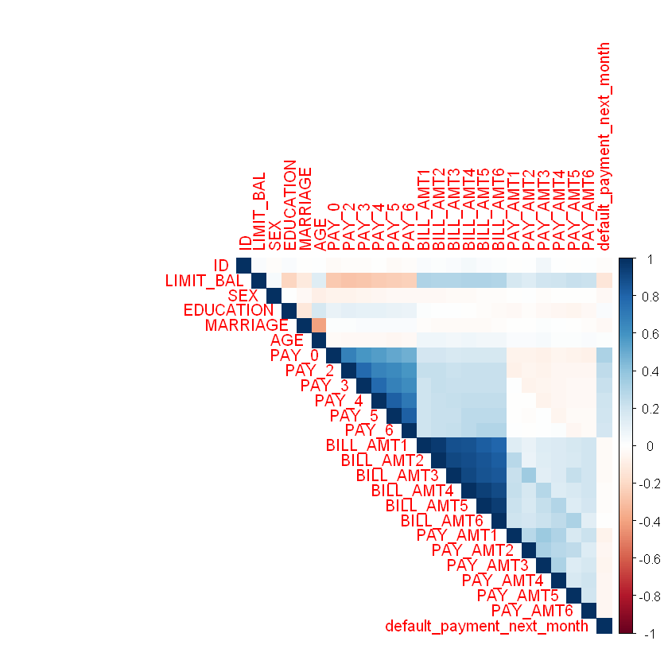

```r
corrplot(cor(train.data), type='upper', method='color')
```

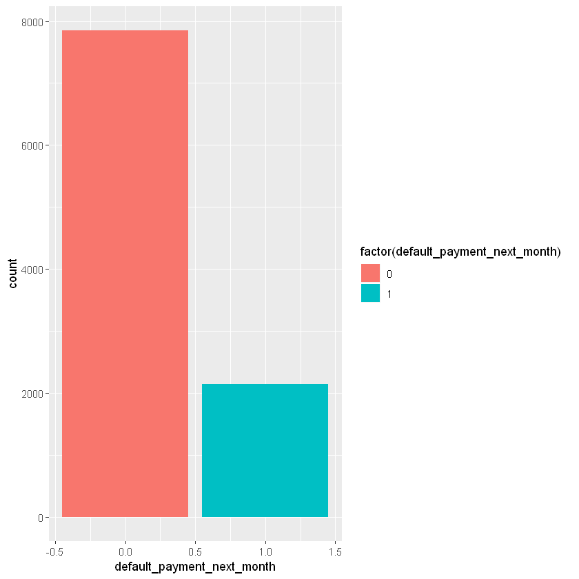

```r
ggplot(train.data, aes(x=default_payment_next_month, fill=factor(default_payment_next_month))) +
  geom_bar()
```

```r
# Fraction defaulted
tibble(percent_default = c(sum(train.data$default_payment_next_month)/dim(train.data)[1]),
       percent_not_default = c(1-sum(train.data$default_payment_next_month)/dim(train.data)[1]))
```

| percent_default | percent_not_default |
| --- | --- |
| 0.2148 | 0.7852 |

To further check if we need to account for class bias, we have also explored the skewness of data within attributes. Most of the attributes are right skewed, as seen in the graphs below. It is important to note that the graph `PAY_AMT1 vs Default Payment Next Month` is filtered because this attribute has several large outliers which makes it difficult to examine the behavior of the data. Thus, the feature allows the behavior of the majority of the training data to become more clear. It is clear that most of the data is right skewed from the graphs below. Note: not all attributes were examined because attributes with a high correlation were assumed to have a similar data distribution.

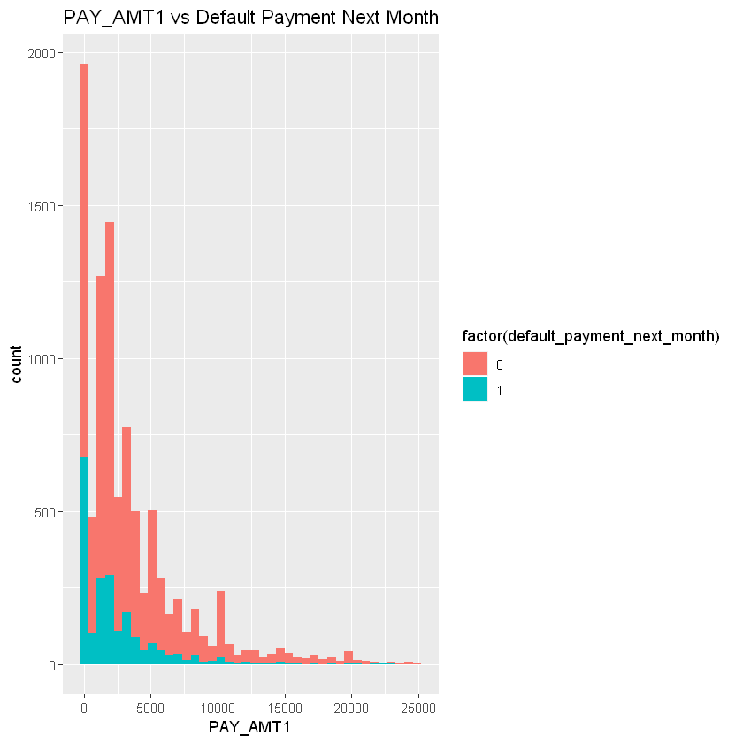

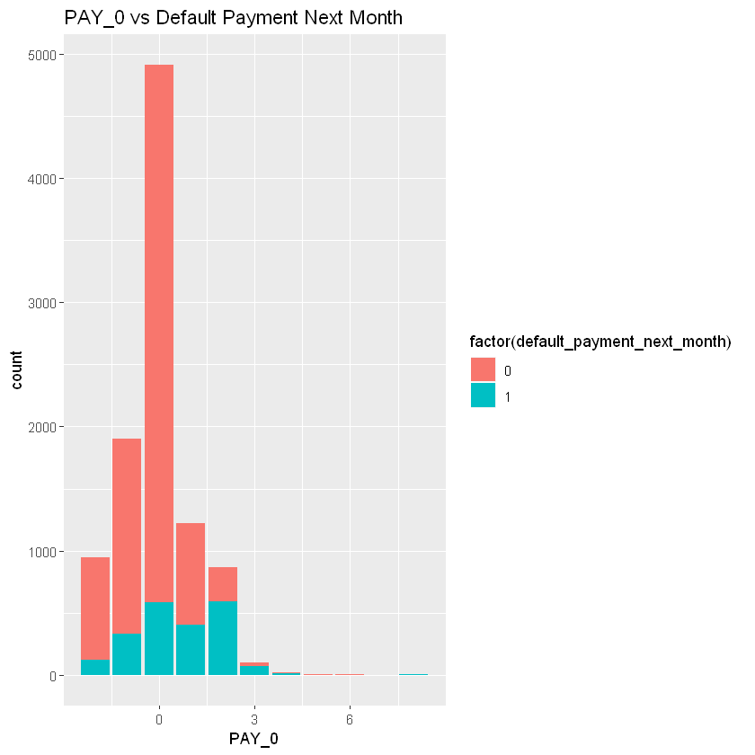

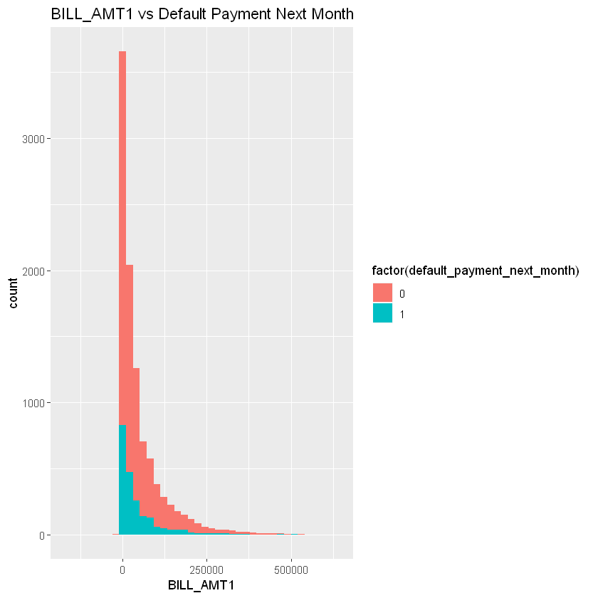

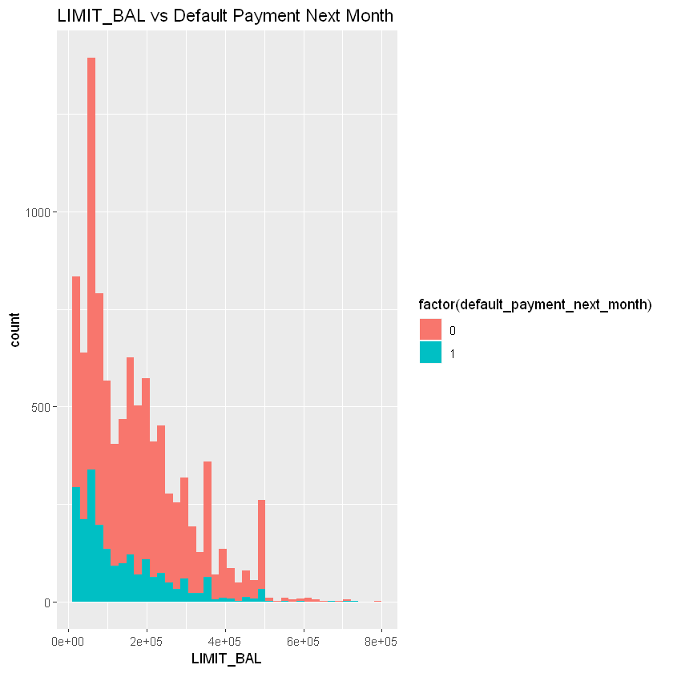

```r
filt_data <- train.data %>% filter(PAY_AMT1 < 25000)
ggplot(filt_data, aes(x=PAY_AMT1, fill=factor(default_payment_next_month))) +
  geom_histogram(bins=40)+
  ggtitle("PAY_AMT1 vs Default Payment Next Month")

ggplot(train.data, aes(x=PAY_0, fill=factor(default_payment_next_month))) +
  geom_bar()+
  ggtitle("PAY_0 vs Default Payment Next Month")

ggplot(train.data, aes(x=BILL_AMT1, fill=factor(default_payment_next_month))) +
  geom_histogram(bins=40)+
  ggtitle("BILL_AMT1 vs Default Payment Next Month")


ggplot(train.data, aes(x=LIMIT_BAL, fill=factor(default_payment_next_month))) +
  geom_histogram(bins=40)+
  ggtitle("LIMIT_BAL vs Default Payment Next Month")
```

Since we see an obvious imbalance of data in the two classes, as well as variables that don’t appear to be normally distributed, we will be taking steps to account for such characteristics. These are documented in the next section for data pre-processing.

## Data Pre-processing

Data pre-processing involves transforming raw data into an understandable format. As the raw data may have several anomalies, there is a need for data to be well prepared so that accurate and effective models can be built. We have attempted to pre-process the dataset through the steps below to get a sense of whether they were helpful for our models. For the purpose of our research, we have decided to proceed with 3 levels of data pre-processing (minimal, mid, intensive).

For minimal-level pre-processing, all we did was make all of the ‘PAY_i’ variables binary. This means we replaced each of these variables with 0 if the individual paid late (e.g. PAY_0 > 0), and replaced this variable with 1 if the individual paid on time.

Next, for mid-level preprocessing, we built upon the minimal-level pre-processing and added ordinal dummies for education. There are 6 dummies for education, each dummy a binary variable for that level of education. We are assuming that an individual with a high educational level would have completed the levels before it. For example, an individual with a graduate school education would have 1 for all the dummy variables, indicating that this individual has completed all levels of education up to and including graduate school.

In addition, we made variables such as sex and marriage binary, where sex=1 if an individual is male and sex=0 if an individual is female. Marriage=1 if an individual is ‘married’ and marriage=0 if an individual is ‘single’ or ‘others’.

Lastly, we chose to down sample our training data upon realization that there is an imbalance in the proportion of default=1 and default=0. More specifically, we have 7852 individuals that have default=0 and only 2148 individuals with default=1. This means that the training model will spend most of its time on the default=0 instead of default=1, which are essentially the individuals that we should worry about.

### Code to pre-process a mid-level amount

```r
# Mid-level code

new_bin_cols <- c("PAY_0", "PAY_2", "PAY_3", "PAY_4", "PAY_5", "PAY_6")
mid_label <- function(x){
  pay_ontime <- 1
  if (x > 0){
    pay_ontime <- 0
  }
  pay_ontime
}

mid_train <- train.data[,-1]
mid_test <- test.data[, -1]

for (col in new_bin_cols){
  mid_train[[col]] <- map_dbl(train.data[[col]], mid_label)
  mid_test[[col]] <- map_dbl(test.data[[col]], mid_label)
}


#Ordinal dummies for education
educationdummies = dummy(mid_train$EDUCATION, sep = ".")
educationdummies = educationdummies[,-1]
for(i in 1:nrow(mid_train)){
  for(j in 1:5){
    if (educationdummies[i,j]==1){
      educationdummies[i,j+1]=1
    }
  }
}
mid_train <- cbind(mid_train, educationdummies)
mid_train <- mid_train[,-3]

mid_train <- mid_train  %>% rename(EDUCATION.1 = NA.1, EDUCATION.2=NA.2, EDUCATION.3=NA.3, ECDUCATION.4=NA.4, EDUCATION.5=NA.5, EDUCATION.6=NA.6)


#Ordinal dummies for education
educationdummies = dummy(mid_test$EDUCATION, sep = ".")
educationdummies = educationdummies[,-1]
for(i in 1:nrow(mid_test)){
  for(j in 1:5){
    if (educationdummies[i,j]==1){
      educationdummies[i,j+1]=1
    }
  }
}
mid_test <- cbind(mid_test, educationdummies)
mid_test <- mid_test[,-3]

mid_test <- mid_test  %>% rename(EDUCATION.1 = NA.1, EDUCATION.2=NA.2, EDUCATION.3=NA.3, ECDUCATION.4=NA.4, EDUCATION.5=NA.5, EDUCATION.6=NA.6)
```

### Code to pre-process an intense-level amount

Note: this isn't shown in the final report, however, it is used to dertmine this amount of preprocessing doesn't work as well.

```r
#Pre-processing Training Set
normalize <- function(x) {
  return ((x - min(x)) / (max(x) - min(x)))
}

intense_train <- train.data
intense_test <- test.data

new_bin_cols <- c("PAY_0", "PAY_2", "PAY_3", "PAY_4", "PAY_5", "PAY_6")
mid_label <- function(x){
  pay_ontime <- 1
  if (x > 0){
    pay_ontime <- 0
  }
  pay_ontime
}


for (col in new_bin_cols){
  intense_train[[col]] <- map_dbl(intense_train[[col]], mid_label)
  intense_test[[col]] <- map_dbl(intense_test[[col]], mid_label)
}



#Make sex 1,0 binary
for(i in 1:nrow(intense_train)){
  if (intense_train$SEX[i]==2){
    intense_train$SEX[i]=0
  }
}

#Make marriage 1,0 binary
for(i in 1:nrow(intense_train)){
  if (intense_train$MARRIAGE[i]==2 | intense_train$MARRIAGE[i]==3){
    intense_train$MARRIAGE[i]=0
  }
}


#Ordinal dummies for education
educationdummies = dummy(intense_train$EDUCATION, sep = ".")
educationdummies = educationdummies[,-1]
for(i in 1:nrow(intense_train)){
  for(j in 1:5){
    if (educationdummies[i,j]==1){
      educationdummies[i,j+1]=1
    }
  }
}
intense_train = cbind(intense_train, educationdummies)
intense_train = intense_train[,-4]
```

```r
intense_train <- intense_train  %>% select(-default_payment_next_month, default_payment_next_month)
```

```r
intense_train$default_payment_next_month <- as.factor(intense_train$default_payment_next_month)
print("Before down sampling")
table(intense_train$default_payment_next_month)
id <- caret::downSample(x = intense_train[, -ncol(intense_train)],
                         y = intense_train$default_payment_next_month)
print("showing training data down sampling size")
table(id$Class)

#intense_train <- id[,-30]
intense_train <- id[, -1]
intense_train <- intense_train  %>% rename(default_payment_next_month=Class)
```

```
[1] "Before down sampling"
```

```
   0    1
7852 2148
```

```
[1] "showing training data down sampling size"
```

```
   0    1
2148 2148
```

```r
# intense_test data set
for(i in 1:nrow(intense_test)){
  if (intense_test$SEX[i]==2){
    intense_test$SEX[i]=0
  }
}

#Make marriage 1,0 binary
for(i in 1:nrow(intense_test)){
  if (intense_test$MARRIAGE[i]==2 | intense_test$MARRIAGE[i]==3){
    intense_test$MARRIAGE[i]=0
  }
}

#Ordinal dummies for education
educationdummies = dummy(intense_test$EDUCATION, sep = ".")
educationdummies = educationdummies[,-1]
for(i in 1:nrow(intense_test)){
  for(j in 1:5){
    if (educationdummies[i,j]==1){
      educationdummies[i,j+1]=1
    }
  }
}
intense_test = cbind(intense_test, educationdummies)
intense_test = intense_test[,-4]

for(i in 1:nrow(intense_test)){
  for(j in 6:11){
    if (intense_test[i,j]<0){
      intense_test[i,j]=0
    }
    else {
      intense_test[i,j]=1
    }
  }
}

intense_test <- intense_test[, -1]
```

```r
intense_train <- intense_train  %>% rename(EDUCATION.1 = NA.1, EDUCATION.2=NA.2, EDUCATION.3=NA.3, ECDUCATION.4=NA.4, EDUCATION.5=NA.5, EDUCATION.6=NA.6)
intense_test <- intense_test  %>% rename(EDUCATION.1 = NA.1, EDUCATION.2=NA.2, EDUCATION.3=NA.3, ECDUCATION.4=NA.4, EDUCATION.5=NA.5, EDUCATION.6=NA.6)
```

```r
head(intense_train)
```

| LIMIT_BAL | SEX | MARRIAGE | AGE | PAY_0 | PAY_2 | PAY_3 | PAY_4 | PAY_5 | PAY_6 | ... | PAY_AMT4 | PAY_AMT5 | PAY_AMT6 | EDUCATION.1 | EDUCATION.2 | EDUCATION.3 | ECDUCATION.4 | EDUCATION.5 | EDUCATION.6 | default_payment_next_month |
| --- | --- | --- | --- | --- | --- | --- | --- | --- | --- | --- | --- | --- | --- | --- | --- | --- | --- | --- | --- | --- |
| 50000 | 0 | 0 | 29 | 1 | 1 | 1 | 1 | 1 | 1 | ... | 6000 | 2675 | 0 | 1 | 1 | 1 | 1 | 1 | 1 | 0 |
| 150000 | 1 | 0 | 28 | 1 | 1 | 1 | 1 | 1 | 1 | ... | 0 | 0 | 901 | 0 | 1 | 1 | 1 | 1 | 1 | 0 |
| 50000 | 0 | 0 | 23 | 1 | 1 | 1 | 1 | 1 | 1 | ... | 310 | 300 | 483 | 1 | 1 | 1 | 1 | 1 | 1 | 0 |
| 220000 | 1 | 0 | 28 | 1 | 1 | 1 | 1 | 1 | 1 | ... | 4000 | 15000 | 3000 | 0 | 1 | 1 | 1 | 1 | 1 | 0 |
| 50000 | 0 | 0 | 50 | 1 | 1 | 1 | 1 | 1 | 1 | ... | 1000 | 3012 | 1503 | 0 | 1 | 1 | 1 | 1 | 1 | 0 |
| 80000 | 1 | 0 | 34 | 1 | 1 | 1 | 1 | 1 | 1 | ... | 2000 | 2000 | 2000 | 0 | 1 | 1 | 1 | 1 | 1 | 0 |

```r
head(intense_test)
```

|  | LIMIT_BAL | SEX | MARRIAGE | AGE | PAY_0 | PAY_2 | PAY_3 | PAY_4 | PAY_5 | PAY_6 | ... | PAY_AMT4 | PAY_AMT5 | PAY_AMT6 | default_payment_next_month | EDUCATION.1 | EDUCATION.2 | EDUCATION.3 | ECDUCATION.4 | EDUCATION.5 | EDUCATION.6 |
| --- | --- | --- | --- | --- | --- | --- | --- | --- | --- | --- | --- | --- | --- | --- | --- | --- | --- | --- | --- | --- | --- |
| 18847 | 130000 | 0 | 1 | 28 | 1 | 1 | 1 | 1 | 1 | 1 | ... | 3100 | 3200 | 3300 | 0 | 0 | 1 | 1 | 1 | 1 | 1 |
| 18895 | 270000 | 0 | 1 | 27 | 1 | 1 | 1 | 1 | 1 | 1 | ... | 10000 | 7000 | 2000 | 0 | 0 | 1 | 1 | 1 | 1 | 1 |
| 26803 | 230000 | 1 | 0 | 28 | 1 | 1 | 1 | 1 | 1 | 1 | ... | 4000 | 1000 | 3000 | 0 | 0 | 1 | 1 | 1 | 1 | 1 |
| 25102 | 150000 | 1 | 1 | 51 | 1 | 1 | 1 | 1 | 1 | 1 | ... | 20000 | 0 | 14500 | 0 | 1 | 1 | 1 | 1 | 1 | 1 |
| 28867 | 310000 | 0 | 1 | 35 | 1 | 1 | 1 | 1 | 1 | 1 | ... | 1100 | 9622 | 0 | 0 | 1 | 1 | 1 | 1 | 1 | 1 |
| 2986 | 120000 | 1 | 0 | 27 | 1 | 1 | 1 | 1 | 1 | 1 | ... | 802 | 640 | 513 | 0 | 0 | 1 | 1 | 1 | 1 | 1 |

## Feature Selection

Since the raw dataset is large, it may be appropriate to reduce the size to improve the efficiency of the machine learning algorithms. This can be done through feature selection, whereby irrelevant features are eliminated.

Since we wanted to choose between using the logistic regression, decision tree, random forest, and bagging models, we performed feature selection for each individual model. This ensured that when we compared the models later we would choose the model that performed the best, since each individual model has different methods of feature selection.

### Helper Functions

These functions make feature selection easier.

```r
# evaluation values
avg_accuracy <- function(actual, preds){
    if (!is.numeric(actual)){
        actual <- as.numeric(actual)-1
    }
    if(!is.numeric(preds)){
        preds <- as.numeric(preds)-1
    }
    tn <- sum((actual == preds) & (actual == 0))
    tp <- sum((actual == preds) & (actual == 1))
    all_ones <- sum(actual)
    all_zeros <- sum(!actual)

    avg_acc <- (tn/all_zeros + tp/all_ones)/2
}
eval_res <- function(actual, preds){
    acc <- Accuracy(preds, actual)
    auroc <- AUC(preds, actual)
    recall <- Recall(actual, preds, positive = "1")
    precision <- Precision(actual, preds, positive = "1")
    #sens <- Sensitivity(actual, preds, positive = "1")
    avg_acc <- avg_accuracy(actual, preds)
    spec <- Specificity(actual, preds, positive = "1")

    c(acc, precision, recall, avg_acc, spec, auroc)
}
```

### Logistic Regression

#### Mid-Level Pre-processing

This code was used to create graphs directly used in the report

```r
mid_train_class <- mid_train$default_payment_next_month
mid_test_class <- mid_test$default_payment_next_month

tmatrix_mid = matrix(0,29,2)

for (i in c(1:22, 24:29)){
  x <- mid_train[,i]
  results <- t.test(x ~ mid_train_class, var.equal=TRUE)
  tmatrix_mid[i,1] <- results$statistic
  tmatrix_mid[i,2] <- results$p.value
  #tmatrix_mid[i,3] <- mid_names[i]
}
ttest_res <-tibble(col=names(mid_train),
                   ttest=tmatrix_mid[,1],
                   pval=tmatrix_mid[,2])
#head(ttest_res)

#ttest.sorted.mid <- tmatrix_mid[order(-tmatrix_mid[,1]),]
ttest_sorted <- ttest_res  %>% arrange(desc(ttest))
#head(ttest_sorted)
# Cols: 2,3,4,5,6,7,8,9,10,11,12,13,14,15,18,19,20,21,22,23,25,27 significant(>1.65)

ttest_sig_vals <- ttest_sorted  %>% filter(ttest > 1.65)
log_reg_cols <- append(ttest_sig_vals$col, 'default_payment_next_month')

logreg2 <- glm(default_payment_next_month~., data = mid_train[log_reg_cols], family=binomial)
summary(logreg2)

log_reg_pred <- predict(logreg2,data=mid_train[log_reg_cols],type="response")
#plotROC(actual=mid_train_class, predictedScores=log_reg_pred)
#0.7508
optcut_mid = optimalCutoff(mid_train_class, log_reg_pred, optimiseFor="misclasserror")
print("Optcut_mid")
optcut_mid
train_mid_binpred =ifelse(log_reg_pred < optcut_mid,0,1)
table(mid_train_class, train_mid_binpred)
p<-eval_res(mid_train_class, train_mid_binpred)

log_res <- tibble(accuracy=p[1],
                  precision=p[2],
                  recall=p[3],
                  avg_accuracy=p[4],
                  specificity=p[5],
                  auroc=p[6])
log_res
#0.8102
```

```
Call:
glm(formula = default_payment_next_month ~ ., family = binomial,
    data = mid_train[log_reg_cols])

Deviance Residuals:
    Min       1Q   Median       3Q      Max
-1.8077  -0.5761  -0.5129  -0.3843   2.9400

Coefficients:
              Estimate Std. Error z value Pr(>|z|)
(Intercept)  1.636e+00  1.553e-01  10.534  < 2e-16 ***
PAY_0       -1.278e+00  7.396e-02 -17.281  < 2e-16 ***
PAY_2       -1.765e-01  1.003e-01  -1.759  0.07862 .
PAY_3       -4.196e-01  9.953e-02  -4.216 2.49e-05 ***
PAY_4       -1.327e-01  1.117e-01  -1.188  0.23465
PAY_5       -3.842e-01  1.194e-01  -3.218  0.00129 **
PAY_6       -4.009e-01  1.028e-01  -3.901 9.57e-05 ***
LIMIT_BAL   -1.212e-06  2.642e-07  -4.587 4.49e-06 ***
PAY_AMT1    -9.942e-06  3.555e-06  -2.797  0.00516 **
PAY_AMT3    -5.763e-06  3.405e-06  -1.693  0.09053 .
PAY_AMT6    -1.034e-06  2.025e-06  -0.511  0.60964
PAY_AMT2    -5.328e-06  3.221e-06  -1.654  0.09810 .
PAY_AMT4    -1.001e-06  2.328e-06  -0.430  0.66714
PAY_AMT5     1.509e-06  2.274e-06   0.663  0.50704
EDUCATION.1  5.607e-03  6.343e-02   0.088  0.92956
MARRIAGE    -1.956e-01  5.260e-02  -3.719  0.00020 ***
SEX         -1.207e-01  5.467e-02  -2.207  0.02732 *
EDUCATION.2 -3.305e-02  7.308e-02  -0.452  0.65115
BILL_AMT1   -6.070e-07  1.810e-06  -0.335  0.73739
BILL_AMT3   -3.027e-07  2.110e-06  -0.143  0.88591
BILL_AMT2    2.692e-06  2.411e-06   1.116  0.26430
BILL_AMT4   -1.127e-06  1.580e-06  -0.713  0.47555
---
Signif. codes:  0 '***' 0.001 '**' 0.01 '*' 0.05 '.' 0.1 ' ' 1

(Dispersion parameter for binomial family taken to be 1)

    Null deviance: 10404.9  on 9999  degrees of freedom
Residual deviance:  8867.5  on 9978  degrees of freedom
AIC: 8911.5

Number of Fisher Scoring iterations: 6
```

```
[1] "Optcut_mid"
```

0.494837875546217

```
               train_mid_binpred
mid_train_class    0    1
              0 7485  367
              1 1523  625
```

| accuracy | precision | recall | avg_accuracy | specificity | auroc |
| --- | --- | --- | --- | --- | --- |
| 0.811 | 0.6300403 | 0.2909683 | 0.6221143 | 0.9532603 | 0.6221143 |

#### Intense-Level Pre-processing

This code was used to make decisions and conclusions in the report.

```r
intense_train_class <- intense_train$default_payment_next_month
intense_test_class <- intense_test$default_payment_next_month

tmatrix_intense = matrix(0,29,2)

for (i in c(1:28)){
  x <- intense_train[,i]
  results <- t.test(x ~ intense_train_class, var.equal=TRUE)
  tmatrix_intense[i,1] <- results$statistic
  tmatrix_intense[i,2] <- results$p.value
  #tmatrix_intense[i,3] <- intense_names[i]
}
intense_ttest_res <-tibble(col=names(intense_train),
                   ttest=tmatrix_intense[,1],
                   pval=tmatrix_intense[,2])
#head(intense_ttest_res)

#ttest.sorted.intense <- tmatrix_intense[order(-tmatrix_intense[,1]),]
ttest_sorted_intense <- intense_ttest_res  %>% arrange(desc(ttest))
#head(ttest_sorted_intense)
# Cols: 2,3,4,5,6,7,8,9,10,11,12,13,14,15,18,19,20,21,22,23,25,27 significant(>1.65)

ttest_sig_vals_intense <- ttest_sorted_intense  %>% filter(ttest > 1.65)
log_reg_cols <- append(ttest_sig_vals_intense$col, 'default_payment_next_month')

logreg2_intense <- glm(default_payment_next_month~., data = intense_train[log_reg_cols], family=binomial)
summary(logreg2_intense)

logreg_preds_intense <- predict(logreg2_intense,data=intense_train[log_reg_cols],type="response")
#plotROC(actual=intense_train_class, predictedScores=logreg_preds_intense)
#0.7508
optcut_intense = optimalCutoff(intense_train_class, logreg_preds_intense, optimiseFor="misclasserror")
print("Optcut_intense")
optcut_intense
train_intense_binpred =ifelse(logreg_preds_intense < optcut_intense,0,1)
table(intense_train_class, train_intense_binpred)
p<-eval_res(intense_train_class, train_intense_binpred)

log_res_intense <- tibble(accuracy=p[1],
                  precision=p[2],
                  recall=p[3],
                  avg_accuracy=p[4],
                  specificity=p[5],
                  auroc=p[6])
log_res_intense
```

```
Call:
glm(formula = default_payment_next_month ~ ., family = binomial,
    data = intense_train[log_reg_cols])

Deviance Residuals:
    Min       1Q   Median       3Q      Max
-2.2244  -0.9505   0.1471   0.9693   2.5288

Coefficients:
              Estimate Std. Error z value Pr(>|z|)
(Intercept)  2.403e+00  1.438e-01  16.709  < 2e-16 ***
PAY_0       -1.218e+00  9.601e-02 -12.688  < 2e-16 ***
PAY_2       -2.689e-01  1.319e-01  -2.038 0.041520 *
PAY_3       -4.172e-01  1.245e-01  -3.350 0.000808 ***
PAY_4       -1.832e-01  1.416e-01  -1.294 0.195759
PAY_5       -3.323e-01  1.569e-01  -2.118 0.034175 *
PAY_6       -3.368e-01  1.371e-01  -2.457 0.014020 *
LIMIT_BAL   -8.511e-07  3.026e-07  -2.813 0.004914 **
PAY_AMT1    -8.171e-06  3.438e-06  -2.377 0.017469 *
PAY_AMT3    -6.382e-06  3.086e-06  -2.068 0.038618 *
PAY_AMT2    -6.000e-06  2.929e-06  -2.048 0.040512 *
PAY_AMT4    -4.488e-07  2.361e-06  -0.190 0.849251
PAY_AMT6     6.266e-08  2.259e-06   0.028 0.977870
EDUCATION.1  8.275e-03  7.825e-02   0.106 0.915772
PAY_AMT5     3.416e-06  2.514e-06   1.359 0.174174
EDUCATION.2 -8.554e-02  9.249e-02  -0.925 0.355071
---
Signif. codes:  0 '***' 0.001 '**' 0.01 '*' 0.05 '.' 0.1 ' ' 1

(Dispersion parameter for binomial family taken to be 1)

    Null deviance: 5955.5  on 4295  degrees of freedom
Residual deviance: 5113.6  on 4280  degrees of freedom
AIC: 5145.6

Number of Fisher Scoring iterations: 4
```

```
[1] "Optcut_intense"
```

0.416409098095492

```
                   train_intense_binpred
intense_train_class    0    1
                  0 1650  498
                  1  800 1348
```

| accuracy | precision | recall | avg_accuracy | specificity | auroc |
| --- | --- | --- | --- | --- | --- |
| 0.6978585 | 0.7302275 | 0.6275605 | 0.6978585 | 0.7681564 | 0.6978585 |

### Decision Tree

**DESCRIPTION**

#### Mid-Level Pre-processing

This is the code that actual produced the tables found in the report.

```r
# code
set.seed(123)
tree <- rpart(default_payment_next_month~., data = mid_train, method = 'class', control = rpart.control(cp = 0.00001))

t_pred <- predict(tree, mid_train, type= "class")
#mean(mid.train.data$`default payment next month` == t_pred)
#mean(mid.test.data$`default payment next month` == t_pred)

#pred = prediction(predict(tree, type = "prob"), mid.test.data)
#roc = performance(t_pred, col= "orange", lwd = 2)

imp <- varImp(tree, scale = FALSE)
tib_imp <- rownames_to_column(imp, "features")
#tib_imp
tree_cols <- tib_imp  %>% arrange(desc(Overall))
print("Cp=0.00001")
tree_cols
tree_cols_sig <- tree_cols  %>% filter(Overall > 0)
new_tree <-prune(tree, cp=0.003)
var2 <- varImp(new_tree, scale=FALSE)
tib_imp2 <- rownames_to_column(var2, "features")
tib_imp2 <- tib_imp2  %>% arrange(desc(Overall))
print("Cp=0.003")
tib_imp2

tree_top <- append(tree_cols_sig$features, "default_payment_next_month")

t_new_pred = predict(new_tree, mid_train, type= "class")
t_pred = predict(tree, mid_train, type= "class")
#mean(mid.train.data$`default payment next month` == t_new_pred)
#mean(mid.test.data$`default payment next month` == t_new_pred)

actual <- mid_train$default_payment_next_month
p<-eval_res(actual, t_new_pred)
res_all <- eval_res(actual, t_pred)

dtc_res <- tibble(features="9 Top Features",
                  accuracy=p[1],
                  precision=p[2],
                  recall=p[3],
                  average_accuracy=p[4],
                  specificity=p[5],
                  auroc=p[6])
dtc_res <- dtc_res  %>% rbind(append("All Features", res_all))
dtc_res
```

[output not shown]

#### Intense-level Pre-processing

This code is referenced in the final report but the tables aren't included.

```r
# code
set.seed(123)
tree_int <- rpart(default_payment_next_month~., data = intense_train, method = 'class', control = rpart.control(cp = 0.00001))

t_pred <- predict(tree_int, intense_train, type= "class")
#mean(mid.train.data$`default payment next month` == t_pred)
#mean(mid.test.data$`default payment next month` == t_pred)

#pred = prediction(predict(tree_int, type = "prob"), mid.test.data)
#roc = performance(t_pred, col= "orange", lwd = 2)

imp_int <- varImp(tree_int, scale = FALSE)
tib_imp_int <- rownames_to_column(imp_int, "features")
#tib_imp_int
tree_int_cols <- tib_imp_int  %>% arrange(desc(Overall))
print("Cp=0.00001")
tree_int_cols
tree_int_cols_sig <- tree_int_cols  %>% filter(Overall > 0)
new_tree_int <-prune(tree_int, cp=0.003)
var2_int <- varImp(new_tree_int, scale=FALSE)
tib_imp_int2 <- rownames_to_column(var2_int, "features")
tib_imp_int2 <- tib_imp_int2  %>% arrange(desc(Overall))
print("Cp=0.003")
tib_imp_int2

tree_int_top <- append(tree_int_cols_sig$features, "default_payment_next_month")

t_new_pred_int = predict(new_tree_int, intense_train, type= "class")
t_pred_int = predict(tree_int, intense_train, type= "class")
#mean(mid.train.data$`default payment next month` == t_new_pred)
#mean(mid.test.data$`default payment next month` == t_new_pred)

actual_int <- intense_train$default_payment_next_month
p_int<-eval_res(actual_int, t_new_pred_int)
res_all_int <- eval_res(actual_int, t_pred_int)

dtc_res_int <- tibble(features="9 Top Features",
                  accuracy=p_int[1],
                  precision=p_int[2],
                  recall=p_int[3],
                  average_accuracy=p_int[4],
                  specificity=p_int[5],
                  auroc=p_int[6])
dtc_res_int <- dtc_res_int  %>% rbind(append("All Features", res_all_int))
dtc_res_int
```

```
[1] "Cp=0.00001"
```

| features | Overall |
| --- | --- |
| PAY_0 | 316.531104 |
| PAY_2 | 268.242158 |
| PAY_3 | 251.003639 |
| BILL_AMT1 | 214.121069 |
| BILL_AMT3 | 206.212465 |
| PAY_AMT2 | 188.586418 |
| PAY_5 | 185.552690 |
| BILL_AMT2 | 175.668450 |
| PAY_4 | 171.788625 |
| PAY_AMT3 | 170.709722 |
| PAY_AMT4 | 159.271091 |
| BILL_AMT6 | 151.991528 |
| BILL_AMT4 | 134.607774 |
| BILL_AMT5 | 134.554649 |
| PAY_AMT1 | 134.366685 |
| AGE | 129.237112 |
| LIMIT_BAL | 128.310951 |
| PAY_AMT5 | 127.036969 |
| PAY_AMT6 | 109.648479 |
| EDUCATION.1 | 36.180023 |
| PAY_6 | 34.153108 |
| SEX | 27.990899 |
| MARRIAGE | 26.592679 |
| EDUCATION.2 | 11.221486 |
| EDUCATION.3 | 6.044329 |
| ECDUCATION.4 | 0.000000 |
| EDUCATION.5 | 0.000000 |
| EDUCATION.6 | 0.000000 |

```
[1] "Cp=0.003"
```

| features | Overall |
| --- | --- |
| PAY_0 | 316.531104 |
| PAY_2 | 263.720289 |
| PAY_3 | 238.883402 |
| PAY_4 | 168.530774 |
| PAY_5 | 168.008380 |
| PAY_AMT3 | 66.145910 |
| PAY_AMT1 | 55.587559 |
| PAY_AMT2 | 50.872682 |
| PAY_AMT4 | 49.890674 |
| BILL_AMT1 | 44.411332 |
| BILL_AMT2 | 27.916713 |
| BILL_AMT3 | 26.887238 |
| PAY_6 | 23.942524 |
| BILL_AMT4 | 22.820896 |
| LIMIT_BAL | 19.265904 |
| BILL_AMT6 | 10.245080 |
| BILL_AMT5 | 5.256893 |
| AGE | 3.122654 |
| PAY_AMT5 | 2.171876 |
| SEX | 0.000000 |
| MARRIAGE | 0.000000 |
| PAY_AMT6 | 0.000000 |
| EDUCATION.1 | 0.000000 |
| EDUCATION.2 | 0.000000 |
| EDUCATION.3 | 0.000000 |
| ECDUCATION.4 | 0.000000 |
| EDUCATION.5 | 0.000000 |
| EDUCATION.6 | 0.000000 |

| features | accuracy | precision | recall | average_accuracy | specificity | auroc |
| --- | --- | --- | --- | --- | --- | --- |
| 9 Top Features | 0.717877094972067 | 0.758278145695364 | 0.639664804469274 | 0.717877094972067 | 0.79608938547486 | 0.717877094972067 |
| All Features | 0.820763500931099 | 0.818686401480111 | 0.824022346368715 | 0.820763500931099 | 0.817504655493482 | 0.820763500931099 |

### Random Forest

#### Helper functions for Random Forest

```r
# helper function

get_feat_info <- function(data_used, test_data){
  cols <- names(data_used)
  #features2 <- cols[cols != 'ID']
  features <- cols[cols != 'default_payment_next_month']
  feat_list <- features



  rf <- randomForest(as.factor(default_payment_next_month)~., data_used)


  feats <- importance(rf)

  rf_vals <- feats[, 1]


  issue_chi <- tibble(features = features, p_val=1:length(features), stat = 1:length(features),
                      ttest = 1:length(features),
                      rf = rf_vals)
  count <- 1
  for (i in features){
    tab <- table(as.factor(data_used[['default_payment_next_month']]), data_used[[i]])
    chi <- chisq.test(tab)
    ttest <- t.test(tab)
    issue_chi$p_val[issue_chi$p_val == count] <-chi$p.value
    issue_chi$stat[issue_chi$stat == count] <-chi$statistic
    issue_chi$ttest[issue_chi$ttest == count] <-ttest$statistic[1]

    count <- count + 1
  }

  issue_chi
}



feat_sel_four <- function(num_feat, results, data_used, test_data, feat){
  actual <- test_data$default_payment_next_month
  sel_feat <- feat.rf$features[1:num_feat]
  update_data <- data_used[append(sel_feat, 'default_payment_next_month')]
  rf2 <- randomForest(as.factor(default_payment_next_month)~., update_data)
  preds2 <- predict(rf2, test_data, type="class")
  p2 <- eval_res(actual, preds2)
  results <- results %>% rbind(append('RF',append(p2, num_feat)))


  sel_feat <- feat.pval$features[1:num_feat]
  update_data <- data_used[append(sel_feat, 'default_payment_next_month')]
  rf3 <- randomForest(as.factor(default_payment_next_month)~., update_data)
  preds3 <- predict(rf3, test_data, type="class")
  p3 <- eval_res(actual, preds3)
  results <- results %>% rbind(append('P-val Chi2',append(p3, num_feat)))


  sel_feat <- feat.chi2$features[1:num_feat]
  update_data <- data_used[append(sel_feat, 'default_payment_next_month')]
  rf4 <- randomForest(as.factor(default_payment_next_month)~., update_data)
  preds4 <- predict(rf4, test_data, type="class")
  p4 <- eval_res(actual, preds4)
  results <- results %>% rbind(append('Chi2',append(p4, num_feat)))



  sel_feat <- feat.ttest$features[1:num_feat]
  update_data <- data_used[append(sel_feat, 'default_payment_next_month')]
  rf5 <- randomForest(as.factor(default_payment_next_month)~., update_data)
  preds5 <- predict(rf5, test_data, type="class")
  p5 <- eval_res(actual, preds5)
  results <- results %>% rbind(append('TTest',append(p5, num_feat)))


  results


}
```

#### Mid-level Pre-processing Data Used

This is the code that is shown in the report and it uses mid-level pre-processing.

```r
set.seed(123)
rf <- randomForest(as.factor(default_payment_next_month)~., mid_train)
actual <- mid_train$default_payment_next_month
preds_rf <- predict(rf, mid_train, type="class")
```

```r
res <- eval_res(actual, preds_rf)
rf_results <- tibble(name=c("All Features"),
                 accuracy=c(res[1]),
                 precision = c(res[2]),
                 recall = c(res[3]),
                 avg_accuracy = c(res[4]),
                 specificity=c(res[5]),
                 auroc=c(res[6]),
                 num_feat="All")
rf_results
```

| name | accuracy | precision | recall | avg_accuracy | specificity | auroc | num_feat |
| --- | --- | --- | --- | --- | --- | --- | --- |
| All Features | 0.9926 | 0.9990375 | 0.9664804 | 0.9831129 | 0.9997453 | 0.9831129 | All |

```r
issue_chi4 <- get_feat_info(mid_train, mid_train)

feat.pval <- issue_chi4[c('features', 'p_val')] %>%  arrange(p_val)
feat.chi2 <- issue_chi4[c('features', 'stat')] %>% arrange(desc(stat))
feat.ttest <- issue_chi4[c('features', 'ttest')] %>% arrange(desc(ttest))
feat.rf <- issue_chi4[c('features', 'rf')] %>% arrange(desc(rf))
```

```r
num_feat <- 15
rf_results <- feat_sel_four(num_feat, rf_results, mid_train, mid_train, feat)
num_feat <- 10
rf_results <- feat_sel_four(num_feat, rf_results, mid_train, mid_train, feat)
num_feat <- 8
rf_results <- feat_sel_four(num_feat, rf_results, mid_train, mid_train, feat)
```

```r
rf_results
```

[output not shown]

```r
rf_top_feat <- append(feat.rf$features[1:10], 'default_payment_next_month')
feat.rf$features[1:10]
```

1. 'BILL_AMT1'

2. 'PAY_0'

3. 'BILL_AMT2'

4. 'AGE'

5. 'BILL_AMT3'

6. 'PAY_AMT1'

7. 'BILL_AMT4'

8. 'LIMIT_BAL'

9. 'BILL_AMT6'

10. 'BILL_AMT5'

```r
rf_best <- randomForest(as.factor(default_payment_next_month)~., mid_train[rf_top_feat])
```

#### Intense-level pre-processing Data Used

This is code not shown directly in the report because it was done originally and helped determine that using mid-level preprocessing was better. The accuracy information is cited in the report.

```r
set.seed(123)
rf_int <- randomForest(as.factor(default_payment_next_month)~., intense_train)
actual_int <- intense_train$default_payment_next_month
preds_rf_int <- predict(rf_int, intense_train, type="class")
```

```r
res_int <- eval_res(actual_int, preds_rf_int)
rf_intense_res <- tibble(name=c("All Features"),
                 accuracy=c(res_int[1]),
                 precision = c(res_int[2]),
                 recall = c(res_int[3]),
                 avg_accuracy = c(res_int[4]),
                 specificity=c(res_int[5]),
                 auroc=c(res_int[6]),
                 num_feat="All")
```

```r
rf_intense_res
```

| name | accuracy | precision | recall | avg_accuracy | specificity | auroc | num_feat |
| --- | --- | --- | --- | --- | --- | --- | --- |
| All Features | 0.9939479 | 0.9880405 | 1 | 0.9939479 | 0.9878957 | 0.9939479 | All |

```r
issue_chi4_int <- get_feat_info(intense_train, intense_train)

feat.pval <- issue_chi4_int[c('features', 'p_val')] %>%  arrange(p_val)
feat.chi2 <- issue_chi4_int[c('features', 'stat')] %>% arrange(desc(stat))
feat.ttest <- issue_chi4_int[c('features', 'ttest')] %>% arrange(desc(ttest))
feat.rf <- issue_chi4_int[c('features', 'rf')] %>% arrange(desc(rf))
```

```r
num_feat <- 15
rf_intense_res <- feat_sel_four(num_feat, rf_intense_res, intense_train, intense_train, feat)
num_feat <- 10
rf_intense_res <- feat_sel_four(num_feat, rf_intense_res, intense_train, intense_train, feat)
num_feat <- 8
rf_intense_res <- feat_sel_four(num_feat, rf_intense_res, intense_train, intense_train, feat)
```

```r
rf_intense_res
```

| name | accuracy | precision | recall | avg_accuracy | specificity | auroc | num_feat |
| --- | --- | --- | --- | --- | --- | --- | --- |
| All Features | 0.993947858472998 | 0.988040478380865 | 1 | 0.993947858472998 | 0.987895716945996 | 0.993947858472998 | All |
| RF | 0.992085661080074 | 0.984862385321101 | 0.999534450651769 | 0.992085661080074 | 0.98463687150838 | 0.992085661080074 | 15 |
| P-val Chi2 | 0.813780260707635 | 0.891405342624855 | 0.714618249534451 | 0.813780260707635 | 0.912942271880819 | 0.813780260707635 | 15 |
| Chi2 | 0.983938547486033 | 0.974874371859296 | 0.993482309124767 | 0.983938547486033 | 0.9743947858473 | 0.983938547486033 | 15 |
| TTest | 0.991620111731844 | 0.983516483516483 | 1 | 0.991620111731844 | 0.983240223463687 | 0.991620111731844 | 15 |
| RF | 0.993482309124767 | 0.987580496780129 | 0.999534450651769 | 0.993482309124767 | 0.987430167597765 | 0.993482309124767 | 10 |
| P-val Chi2 | 0.723463687150838 | 0.775229357798165 | 0.629422718808194 | 0.723463687150838 | 0.817504655493482 | 0.723463687150838 | 10 |
| Chi2 | 0.982541899441341 | 0.970494779845665 | 0.995344506517691 | 0.982541899441341 | 0.969739292364991 | 0.982541899441341 | 10 |
| TTest | 0.997206703910615 | 0.994444444444444 | 1 | 0.997206703910615 | 0.994413407821229 | 0.997206703910615 | 10 |
| RF | 0.989990689013035 | 0.981252857796068 | 0.999068901303538 | 0.989990689013035 | 0.980912476722533 | 0.989990689013035 | 8 |
| P-val Chi2 | 0.707867783985102 | 0.750140056022409 | 0.623370577281192 | 0.707867783985102 | 0.792364990689013 | 0.707867783985102 | 8 |
| Chi2 | 0.981843575418994 | 0.969174977334542 | 0.995344506517691 | 0.981843575418994 | 0.968342644320298 | 0.981843575418994 | 8 |
| TTest | 0.988361266294227 | 0.977686703096539 | 0.999534450651769 | 0.988361266294227 | 0.977188081936685 | 0.988361266294227 | 8 |

```r
rf_top_int <- append(feat.rf$features[1:10], 'default_payment_next_month')
feat.rf$features[1:10]
```

1. 'PAY_0'

2. 'BILL_AMT1'

3. 'BILL_AMT2'

4. 'PAY_AMT2'

5. 'PAY_AMT1'

6. 'AGE'

7. 'LIMIT_BAL'

8. 'BILL_AMT3'

9. 'BILL_AMT4'

10. 'BILL_AMT6'

```r
rf_best_int <- randomForest(as.factor(default_payment_next_month)~., intense_train[rf_top_int])
```

### Bagging

The variable importance function was used to find the top 18 features with the highest importance. The top 18 features were all of the attributes except for `Marriage`, `Education.1`, `Education.2`, `Education.3`, `Education.4`, `Education.5`, `Education.6`, `Sex`, `Pay_6`, and `Pay_4`. This is shown in the importance output given below.

#### Mid-Level Pre-processing Data

This is the code used in the actual report.

```r
# bagging model
set.seed(123)
baggedtree<-bagging(as.factor(mid_train$default_payment_next_month)~.,nbagg=100,data =mid_train )

# Get the importance of features
imp <- varImp(baggedtree)
# turn output of importance features into a tibble
imp_tib <-rownames_to_column(imp, "features")
# arrange the results in descending order
imp_tib <-imp_tib  %>% arrange(desc(Overall))
# add an ranking index for clarity
imp_tib['index'] <- c(1:nrow(imp_tib))
```

```r
imp_tib
```

| features | Overall | index |
| --- | --- | --- |
| BILL_AMT1 | 1.033764e+03 | 1 |
| BILL_AMT2 | 9.555995e+02 | 2 |
| BILL_AMT3 | 8.501247e+02 | 3 |
| AGE | 8.108087e+02 | 4 |
| LIMIT_BAL | 7.524881e+02 | 5 |
| BILL_AMT4 | 7.264613e+02 | 6 |
| BILL_AMT5 | 6.603683e+02 | 7 |
| BILL_AMT6 | 6.248282e+02 | 8 |
| PAY_AMT1 | 6.064957e+02 | 9 |
| PAY_AMT2 | 5.731326e+02 | 10 |
| PAY_AMT3 | 5.545722e+02 | 11 |
| PAY_AMT4 | 5.076972e+02 | 12 |
| PAY_AMT5 | 5.027224e+02 | 13 |
| PAY_AMT6 | 4.887796e+02 | 14 |
| PAY_2 | 4.543760e+02 | 15 |
| PAY_0 | 4.410745e+02 | 16 |
| PAY_3 | 3.804640e+02 | 17 |
| PAY_5 | 3.734830e+02 | 18 |
| PAY_4 | 3.317342e+02 | 19 |
| MARRIAGE | 2.003380e+02 | 20 |
| SEX | 1.821860e+02 | 21 |
| PAY_6 | 1.487914e+02 | 22 |
| EDUCATION.1 | 1.025743e+02 | 23 |
| EDUCATION.2 | 8.833509e+01 | 24 |
| EDUCATION.3 | 1.100627e+01 | 25 |
| ECDUCATION.4 | 7.807790e+00 | 26 |
| EDUCATION.5 | 3.708468e+00 | 27 |
| EDUCATION.6 | 3.555556e-02 | 28 |

```r
top_n_feat <- imp_tib$features[1:18]
top_n_feat
```

1. 'BILL_AMT1'

2. 'BILL_AMT2'

3. 'BILL_AMT3'

4. 'AGE'

5. 'LIMIT_BAL'

6. 'BILL_AMT4'

7. 'BILL_AMT5'

8. 'BILL_AMT6'

9. 'PAY_AMT1'

10. 'PAY_AMT2'

11. 'PAY_AMT3'

12. 'PAY_AMT4'

13. 'PAY_AMT5'

14. 'PAY_AMT6'

15. 'PAY_2'

16. 'PAY_0'

17. 'PAY_3'

18. 'PAY_5'

After removing the less important features (`Marriage`, `Education.1`, `Education.2`, `Education.3`, `Education.4`, `Education.5`, `Education.6`, `Sex`, `Pay_6`, and `Pay_4`), the accuracy for the training data was found to be 0.803, the area under the ROC was found to be 0.640, recall was found to be 0.926. Using all of the features, the bagging model had an accuracy of 0.804, an area under the ROC of 0.636, a recall score of 0.931, and a precision score of 0.838. Thus, using only 18 features outperformed using all of the features for auroc and precision. However, the two recall and accuracy scores were very close together so using only 18 features produced the best bagging model.

```r
# Training the new bagging model with less features
bag_18_feat <- bagging(as.factor(mid_train$default_payment_next_month)~.,nbagg=100,data =mid_train[top_n_feat])
```

```r
# accuracy, area under ROC, and Precision
y_actual <- mid_train$default_payment_next_month
preds__bag_18 <- predict(bag_18_feat, data=mid_train, type="class")
preds_bag <- predict(baggedtree, data=mid_train, type="class")
```

```r
# accuracy, area under ROC, and Precision
res <- eval_res(y_actual, preds_bag)
res_18 <- eval_res(y_actual, preds_bag_18)
bagging_results <- tibble(name=c("All Features", "Top 18 Features"),
                 accuracy=c(res[1], res_18[1]),
                 precision = c(res[2], res_18[2]),
                 recall = c(res[3], res_18[3]),
                 sensitivity = c(res[4], res_18[4]),
                 specificity = c(res[5], res_18[5]),
                 auroc = c(res[6], res_18[6]))
bagging_results
```

[output not shown]

```r
#plotROC(as.numeric(y_actual), as.numeric(preds))
```

```r
#plotROC(as.numeric(y_actual), as.numeric(preds_18))
```

#### Intense-Level Pre-processing Data

```r
# bagging model
set.seed(123)
bt_intense<-bagging(as.factor(intense_train$default_payment_next_month)~.,nbagg=100,data =intense_train )

# Get the importance of features
imp <- varImp(bt_intense)
# turn output of importance features into a tibble
imp_tib <-rownames_to_column(imp, "features")
# arrange the results in descending order
imp_tib <-imp_tib  %>% arrange(desc(Overall))
# add an ranking index for clarity
imp_tib['index'] <- c(1:nrow(imp_tib))
```

```r
imp_tib
```

| features | Overall | index |
| --- | --- | --- |
| BILL_AMT1 | 625.24977903 | 1 |
| BILL_AMT2 | 582.44497809 | 2 |
| BILL_AMT3 | 535.35614760 | 3 |
| AGE | 501.26898365 | 4 |
| BILL_AMT4 | 473.52249219 | 5 |
| LIMIT_BAL | 467.72681232 | 6 |
| BILL_AMT5 | 424.00353125 | 7 |
| PAY_AMT2 | 414.23443053 | 8 |
| BILL_AMT6 | 408.44151080 | 9 |
| PAY_AMT1 | 406.58695180 | 10 |
| PAY_AMT3 | 372.84197675 | 11 |
| PAY_AMT4 | 351.24526571 | 12 |
| PAY_AMT5 | 319.42395280 | 13 |
| PAY_0 | 317.28597831 | 14 |
| PAY_AMT6 | 315.06917379 | 15 |
| PAY_2 | 296.77743891 | 16 |
| PAY_3 | 260.67822466 | 17 |
| PAY_5 | 208.46173915 | 18 |
| PAY_4 | 204.17314379 | 19 |
| MARRIAGE | 107.54949968 | 20 |
| SEX | 105.69921824 | 21 |
| PAY_6 | 74.49310041 | 22 |
| EDUCATION.1 | 65.86213863 | 23 |
| EDUCATION.2 | 50.12135209 | 24 |
| EDUCATION.3 | 15.65404911 | 25 |
| ECDUCATION.4 | 8.58564450 | 26 |
| EDUCATION.5 | 2.01312300 | 27 |
| EDUCATION.6 | 0.08928856 | 28 |

```r
top_n_feat_int <- imp_tib$features[1:18]
top_n_feat_int
```

1. 'BILL_AMT1'

2. 'BILL_AMT2'

3. 'BILL_AMT3'

4. 'AGE'

5. 'BILL_AMT4'

6. 'LIMIT_BAL'

7. 'BILL_AMT5'

8. 'PAY_AMT2'

9. 'BILL_AMT6'

10. 'PAY_AMT1'

11. 'PAY_AMT3'

12. 'PAY_AMT4'

13. 'PAY_AMT5'

14. 'PAY_0'

15. 'PAY_AMT6'

16. 'PAY_2'

17. 'PAY_3'

18. 'PAY_5'

```r
# Training the new bagging model with less features
bag_18_int <- bagging(as.factor(intense_train$default_payment_next_month)~.,nbagg=100,data =intense_train[top_n_feat])
```

```r
# accuracy, area under ROC, and Precision
y_actual <- intense_train$default_payment_next_month
preds_bag_18_int <- predict(bag_18_int, data=intense_train, type="class")
preds_bag_int <- predict(bt_intense, data=intense_train, type="class")
```

```r
# accuracy, area under ROC, and Precision
res_int <- eval_res(y_actual, preds_bag_int)
res_18_int <- eval_res(y_actual, preds_bag_18_int)
bagging_results_int <- tibble(name=c("All Features", "Top 18 Features"),
                 accuracy=c(res_int[1], res_18_int[1]),
                 precision = c(res_int[2], res_18_int[2]),
                 recall = c(res_int[3], res_18_int[3]),
                 avg_accuracy = c(res_int[4], res_18_int[4]),
                 specificity = c(res_int[5], res_18_int[5]),
                 auroc = c(res_int[6], res_18_int[6]))
bagging_results_int
```

| name | accuracy | precision | recall | avg_accuracy | specificity | auroc |
| --- | --- | --- | --- | --- | --- | --- |
| All Features | 0.6815642 | 0.6959799 | 0.6447858 | 0.6815642 | 0.7183426 | 0.6815642 |
| Top 18 Features | 0.6259311 | 0.6325331 | 0.6010242 | 0.6259311 | 0.6508380 | 0.6259311 |

## Model Selection

### Mid Level Pre-Processed Data Used

This is the code used in the final report to determine the final conclusion about the model selection.

```r
# get the predictions for test data set
actual <- mid_test$default_payment_next_month
preds_rf <- predict(rf_best, mid_test)
preds_bag <- predict(bag_18_feat, mid_test)


preds_dtc <- predict(tree, mid_test, type="class")

test_mid_pred <- predict(logreg2, newdata=mid_test[log_reg_cols],type="response")
#plotROC(actual=mid.test.class, predictedScores=test.mid.pred)
#0.7538
test_optcut_mid <- optimalCutoff(actual, test_mid_pred, optimiseFor="misclasserror")
#test.optcut.mid
preds_log_reg <- ifelse(test_mid_pred < test_optcut_mid,0,1)
```

```r
rf_res <- eval_res(actual, preds_rf)
bag_res <- eval_res(actual, preds_bag)
log_res <- eval_res(actual, preds_log_reg)
dtc_res <- eval_res(actual, preds_dtc)
```

```r
# create a table of the results
model_sel_res <- tibble(name='Random Forest',
                        accuracy=rf_res[1],
                        precision=rf_res[2],
                        recall=rf_res[3],
                        avg_accuracy=rf_res[4],
                        specifity=rf_res[5],
                        auroc=rf_res[6])
model_sel_res <- model_sel_res  %>% rbind(append("Bagging", bag_res))
model_sel_res <- model_sel_res  %>% rbind(append("Logistic Regression", log_res))
model_sel_res <- model_sel_res  %>% rbind(append("Decision Tree", dtc_res))
print("Table X")
model_sel_res
```

[output not shown]

```r
print("Random Forest")
ConfusionMatrix(preds_rf, actual)
```

```
[1] "Random Forest"
```

```
      y_pred
y_true     0     1
     0 14594   918
     1  3034  1454
```

```r
print("Bagging")
ConfusionMatrix(preds_bag, actual)
```

```
[1] "Bagging"
```

```
      y_pred
y_true     0     1
     0 14447  1065
     1  2927  1561
```

```r
print("Logistic Regression")
ConfusionMatrix(preds_log_reg, actual)
```

[output not shown]

```r
print("Decision Tree")
ConfusionMatrix(preds_dtc, actual)
```

[output not shown]

### Intense Level Pre-Processed Data Used

This was not directly used in the final report, however this is where the conclusion that using mid-level pre-processing comes from.

```r
# get the predictions for test data set
actual_int <- intense_test$default_payment_next_month
preds_rf_int <- predict(rf_best_int, intense_test)
preds_bag_int <- predict(bag_18_int, intense_test)

preds_dtc_int <- predict(tree_int, intense_test, type="class")

test_int_pred <- predict(logreg2_intense, newdata=intense_test[log_reg_cols],type="response")
#plotROC(actual_int=mid.test.class, predictedScores=test.mid.pred)
#0.7538
test_optcut_int <- optimalCutoff(actual_int, test_int_pred, optimiseFor="misclasserror")
#test.optcut.mid
preds_log_reg_int <- ifelse(test_int_pred < test_optcut_int,0,1)
```

```r
rf_res_int <- eval_res(actual_int, preds_rf_int)
bag_res_int <- eval_res(actual_int, preds_bag_int)
log_res_int <- eval_res(actual_int, preds_log_reg_int)
dtc_res_int <- eval_res(actual_int, preds_dtc_int)

# create a table of the results
model_sel_res_int <- tibble(name='Random Forest',
                        accuracy=rf_res_int[1],
                        precision=rf_res_int[2],
                        recall=rf_res_int[3],
                        avg_accuracy=rf_res_int[4],
                        specifity=rf_res_int[5],
                        auroc=rf_res_int[6])
model_sel_res_int <- model_sel_res_int  %>% rbind(append("Bagging", bag_res_int))
model_sel_res_int <- model_sel_res_int  %>% rbind(append("Logistic Regression", log_res_int))
model_sel_res_int <- model_sel_res_int  %>% rbind(append("Decision Tree_int", dtc_res_int))
print("Table X - Intense Level")
model_sel_res_int
```

```
[1] "Table X - Intense Level"
```

| name | accuracy | precision | recall | avg_accuracy | specifity | auroc |
| --- | --- | --- | --- | --- | --- | --- |
| Random Forest | 0.7052 | 0.36158081006685 | 0.40975935828877 | 0.600218771460012 | 0.790678184631253 | 0.600218771460012 |
| Bagging | 0.6724 | 0.363492063492063 | 0.612299465240642 | 0.651044008020011 | 0.689788550799381 | 0.651044008020011 |
| Logistic Regression | 0.77555 | 0 | 0 | 0.49996776689015 | 0.999935533780299 | 0.49996776689015 |
| Decision Tree_int | 0.63655 | 0.273571079628725 | 0.374331550802139 | 0.543373872358264 | 0.712416193914389 | 0.543373872358264 |

```r
print("Random Forest")
ConfusionMatrix(preds_rf_int, actual_int)
```

```
[1] "Random Forest"
```

```
      y_pred
y_true     0     1
     0 12265  3247
     1  2649  1839
```

```r
print("Bagging")
ConfusionMatrix(preds_rf_int, actual_int)
```

[output not shown]

```
      y_pred
y_true     0     1
     0 12265  3247
     1  2649  1839
```

```r
print("Logistic Regression")
ConfusionMatrix(preds_log_reg_int, actual_int)
```

```
[1] "Logistic Regression"
```

```
      y_pred
y_true     0     1
     0 15511     1
     1  4488     0
```

```r
print("Decision Tree")
ConfusionMatrix(preds_dtc_int, actual_int)
```

```
[1] "Decision Tree"
```

```
      y_pred
y_true     0     1
     0 11051  4461
     1  2808  1680
```

## Model Evaluation

### Mid-level Pre-processing

```r
model_sel_res[2,]
```

[output not shown]

```r
print("Bagging")
ConfusionMatrix(preds_bag, actual)
```

[output not shown]

### Intense-level Pre-processing

Now that the Bagging model has been selected, it needs to be evaluated. This was done by predicting the values of the test data set and determining the accuracy and area under the ROC for those predictions. In this case, the bagging model had an 65.1% average accuracy and 67.2% raw accuracy with the test data and an area under the ROC score of 0.651. This is a pretty good performance of the test data set. However, the fact that the precision score is so low indicates that the model still has a difficult time predicting when clients default correctly.

```r
model_sel_res_int[2,]
```

| name | accuracy | precision | recall | avg_accuracy | specifity | auroc |
| --- | --- | --- | --- | --- | --- | --- |
| Bagging | 0.6724 | 0.363492063492063 | 0.612299465240642 | 0.651044008020011 | 0.689788550799381 | 0.651044008020011 |

```r
print("Bagging")
ConfusionMatrix(preds_bag_int, actual_int)
```

```
[1] "Bagging"
```

```
      y_pred
y_true     0     1
     0 10700  4812
     1  1740  2748
```

## Future Improvements

There are some rooms for improvement that we have considered:

- There were many more class 0 data than class 1 data in the dataset which meant that the accuracy of our models could have been skewed towards correct prediction of class 0 data. This means that we could have used harmonic mean to calculate accuracy so as to mitigate bias towards class 0 prediction.
- Instead of splitting the data into training and test data, if more data was given, we would be able to split our training data further into training and validation data set. This is so that when we fit a model on the training data, we can then use the fitted model to predict responses in the validation data, and tune the features in the model, before moving on to the test data.